# An Analysis on College Accessibility

Maxim Chiao

June 10, 2019

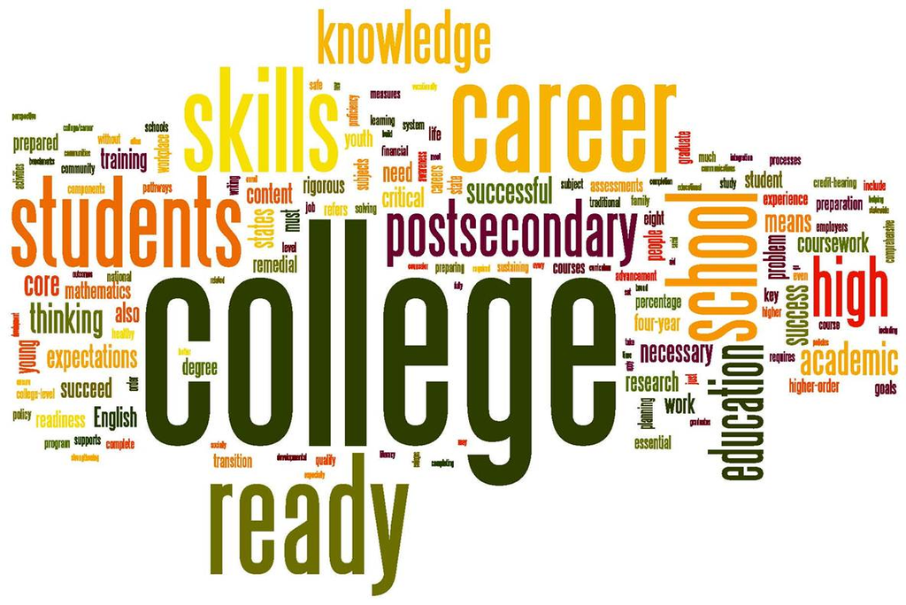

https://blog.e-bikerig.com/wp-content/uploads/2015/11/college-bike.jpg

### Table of Contents

- Abstract
- Data Context and Historical Background
- Exploratory Data Analysis
  - Structures, Patterns, and Anomalies
  - Variance
  - Additional Data and Insights
  - Data Issues
- Key Findings
- Conclusions and Further Research
- Bibliography

# *Abstract*

I explored the college scorecard data published by the U.S. Department of Education (DOE). I used a subset of this data specific to California institutions and examined the rates of retention and completion of full-time, first time Title IV students. I explored the available financial categories of this dataset to attempt to find a correlation between them and the aforementioned rates of retention and completion. The relevant data used spanned from the years 2011 to 2017, the seven most recent years made available by the DOE. I chose to start at 2011 since it is the earliest year with the most modern variables and definitions. I focused more attention to the trends of public institutions: California State University (CSU) campuses, University of California (UC) campuses, community colleges, etc. I analyzed the trends of all California campuses, public and private, but specifically grouped the public campuses together as they are the more populated campuses and provided better data about the California postsecondary education system than private campuses.

News reports and individual criticism suggest that universities are becoming increasingly corporate, focusing more on profit than on education. Tuition costs have been on the rise over the last several years and paying for higher education is becoming more and more difficult. Large campuses like the UC campuses are admitting an increasing number of out of state and international students - the groups of students who pay the highest tuition - a sign to some that the administrators are trying to maximize profits. If true, this trend of corporatization of institutions creates a rift in the accessibility of higher education.

This topic is currently an important area of study because the demand for a college degree in the workplace is increasing and obtaining said degree is becoming more expensive. The rise in student expenses not only burdens current students but the prospective costs will also deter and prevent potential students from enrolling in higher education. College and higher education is becoming seemingly more and more inaccessible as the obligations become greater. It is important to see what areas contribute to inaccessibility and the effects of those areas on the student body. This research contributes to our understanding of the economics at play in the educational system and their correlation to educational accessibility.

# *Data Context and Historical Background*

The College Scorecard Data is an online [tool](https://collegescorecard.ed.gov/) and data set provided by the United States Department of Education to allow the public access to quantifiable data about different colleges and universities. The data set provides historical data about campuses and their student body from the last twenty years. Though, it must be noted that the data collection is centralized around Title IV, or federal financial aid receiving, strudents. The data set itself and corresponding tool were not launched until 2015 under the Obama administration as a way to redefine how we compare colleges. Before the launch of the College Scorecard Data website, all college rankings were done by third parties like U.S. News and Princeton Review, who use ambiguous and inconsistent metrics for calculating the rankings (Zhou 2015). Using data from the Integrated Postsecondary Education Data System (IPEDS), National Student Loan Data System (NSLDS), and the Department of Treasury; the Department of Education aggregates the data together and publishes the federal data on their website.

There are currently no laws in place to mandate the collection, aggregation, and/or publication of data, however there is an executive order put in place by President Obama that accomplishes the same task. During the Obama administration, there was a big push toward open, transparent federal data for the public. This movement was named the Open Government Initiative. The mandates of the Open Government Initiative require government agencies to publish open, machine-readable data for public consumption. The IPEDS, NSLDS, and the Department of Treasury all fall under the jurisdiction of this executive order and because of this, their data was made open and the creation of the Scorecard was possible. Given the types of data that the College Scorecard wanted to make available, the Department of Education and the Department of Treasury had to share data between themselves in order to aggregate the data collected by each department individually into a single data set that would provide metrics of comparison for different postsecondary institutions.

Since the College Scorecard came during the time of the Open Government Initiative, there was an obligation, through executive order, for access to transparent, machine-readable federal data. The Obama administration wanted to provide reliable and accessible data on colleges so anyone would be able to compare colleges using features like graduation rates, tuition, and loan repayment. The IPEDS collects its data annually through surveys administered by the National Center for Education Statistics. Because of the Higher Education Act, institutions that participated in Title IV federal student aid programs are required to complete IPEDS questionnaires. The NSLDS collects its loan data from federal loan and grant information systems and also utilizes Free Application for Federal Student Aid information to collect student demographic information. The methods of data collection has not changed since the launch of the Scorecard, but the IPEDS has added more sections to its survey, like Outcome Measures, which provided more data on completion, transfers, and continued enrollment of full-time first-time students (“Documentation College Scorecard Data” 2019). The College Scorecard uses metrics derived from the annual reports of the IPEDS and NSLDS data to create their own annually updated data set of discrete data values, rather than ambiguous categories, that is a more reliable and accessible means of assessing affordability and value of colleges.

The data set is not without its flaws. The data set only represents a small subset of the total student body population due to the limitations of the group sampled for data collection. Focused on Title IV, undergraduate students, the data set a significant amount of the student population. Some estimates have a value of only about 50 percent of students represented (Rothwell 2015).

# *Exploratory Data Analysis*

```r
# College Scorecard data filtered to California institutitons
ca_2011 <- read.csv("CA2010-11.csv", stringsAsFactors = FALSE) %>% mutate(YEAR = 2011)
ca_2012 <- read.csv("CA2011-12.csv", stringsAsFactors = FALSE) %>% mutate(YEAR = 2012)
ca_2013 <- read.csv("CA2012-13.csv", stringsAsFactors = FALSE) %>% mutate(YEAR = 2013)
ca_2014 <- read.csv("CA2013-14.csv", stringsAsFactors = FALSE) %>% mutate(YEAR = 2014)
ca_2015 <- read.csv("CA2014-15.csv", stringsAsFactors = FALSE) %>% mutate(YEAR = 2015)
ca_2016 <- read.csv("CA2015-16.csv", stringsAsFactors = FALSE) %>% mutate(YEAR = 2016)
ca_2017 <- read.csv("CA2016-17.csv", stringsAsFactors = FALSE) %>% mutate(YEAR = 2017)

ca_total <- rbind(ca_2011,ca_2012,ca_2013,ca_2014,ca_2015,ca_2016,ca_2017)

# Selecting desired columns
ca_total <- ca_total %>% select(UNITID, INSTNM, CONTROL, OPENADMP, DISTANCEONLY, ICLEVEL, ADM_RATE,
                                starts_with("UGDS"), RET_FT4, RET_FTL4, MEDIAN_HH_INC, LOAN_EVER,
                                ends_with("_MDN"), ends_with("_N"), CDR2 , CDR3, contains("RPY"),
                                ends_with("_PUB"), ends_with("_PRIV"), COSTT4_A, TUITIONFEE_IN
                                , TUITIONFEE_OUT, INEXPFTE, TUITFTE, PCTFLOAN, starts_with("C150_"),
                                YEAR, -ends_with("NH"), -ends_with("OLD"), -ends_with("API"),
                                -ends_with("PROG"), -ends_with("SUPP"), -ends_with("POOLED"),
                                -contains("DT"))
```

```r
# 2 or 4 Year Institutions Only
ca_total <- ca_total %>% filter(ICLEVEL < 3)
```

```r
# Separating in to public and private institutions subsets
ca_public <- ca_total %>% filter(CONTROL==1)
ca_private <- ca_total %>% filter(CONTROL > 1)
```

### Structures, Patterns, and Anomalies

My data set is one that consists of rows that represent individual institutions, unique to the physical location of the campus, rather than institution name, for any given year. The columns in my particular data set are variables that describe different characteristics of an institution. Some of these can be related to the school as an entity like the name, its revenue and expenditures, and whether it’s a public, private for-profit, or private non-profit institution. Others are related to the students such as demographics, cost of attendance, and in- and out-of-state tuition.

One of the most notable missing values come from the column that represents share of Asian Pacific Islander undergraduate, degree-seeking students. For several years in the data set, that variable is null for every school in the dataset. Since it was unlikely that schools stopped reporting data for this particular demographic, I hypothesized that since the source data goes back so many years that the categorization of this demographic may have changed over time and that column was kept in the data set to preserve the historical data. Reading into the data dictionary, and the definitions of the different demographic variables and confirmed that the categorical definition of this demographic changed from Asian Pacific Islander to Native Hawaiian/Pacific Islander.

A large amount of financial data was missing from my data set, from both public and private colleges. Both subsets of college types had entries within them that were missing some value, whether it be retention rates, default rates, and/or financial information like an institution’s spending and revenue. For private institutions, the percentage of values that were NA was higher than that of the public institutions. It is not possible to tell the cause of all these missing values with the data that I have. There is no way to verify the true meanings of these missing values. One possibility is could be a choice to refuse to disclose the information, but it could also be equally as likely that a given college does not have the data to release because they do not calculate for that given variable in the data set.

To both the private school and public school data sets that I made, I applied a mutate function call where I summed up the shares of all minority groups in each institution. I calculated the average share of minority undergraduates for all schools in a given data set for each year by calling summarize and taking the mean of the new column I created with the mutate call. As a result, I was able to see the average percentage minority students in each year and how the value changed over time. What this showed me is that share that minority students hold has been increasing in public schools and decreasing in private schools over time. This directly relates back to an issue in my research abstract regarding the accessibility of higher education. The percentage of minority students can be used as a metric for accessibility in my research project and can be potentially correlated with financial data.

```r
ca_total <- ca_total %>% mutate(PCT_MIN = UGDS_BLACK+UGDS_HISP+UGDS_AIAN+UGDS_ASIAN+UGDS_NHPI+UGDS_2MOR)
ca_total <- ca_total %>% mutate(UGDS_MIN = PCT_MIN * UGDS)
```

By grouping the data by year and calling a summarize to get the average cost of attendance, average net cost, and average aid (obtained by subtracting net cost from cost of attendance) per year for all institutions in the public school data set. What this has shown me is that cost of attendance, net cost, and aid have all been increasing in recent years. Again, this can also relate back to the issue of accessibility of higher education. In this case, I could use the data to get a sense of change over time for each category and compare the rates of change for each of them. If one rate of change for one metric outpaces another, that could give me insight on the state of accessibility. For example, if cost rises faster than aid, then it could be said that school is becoming less accessible. We can further examine other variables to try to come to a similar insights on the topic of accessibility.

### Variation

The first plot is a waffle chart. By calculating the number of each type of institution and putting it over the total number of institutions, we obtain the percentage share of each type of institution. By creating this waffle chart, we are able to visually represent the share of each type of California institution by control where each square represents a one percent share. From this, we can see that public institutions actually have the smallest share out of all institutions at around a 30 percent share. Since it is well known that the cost of private schools is, on average, higher than that of public schools, one could use this information and insight to make an argument about how private schools’ majority share affects the affordability and accessibility of higher education.

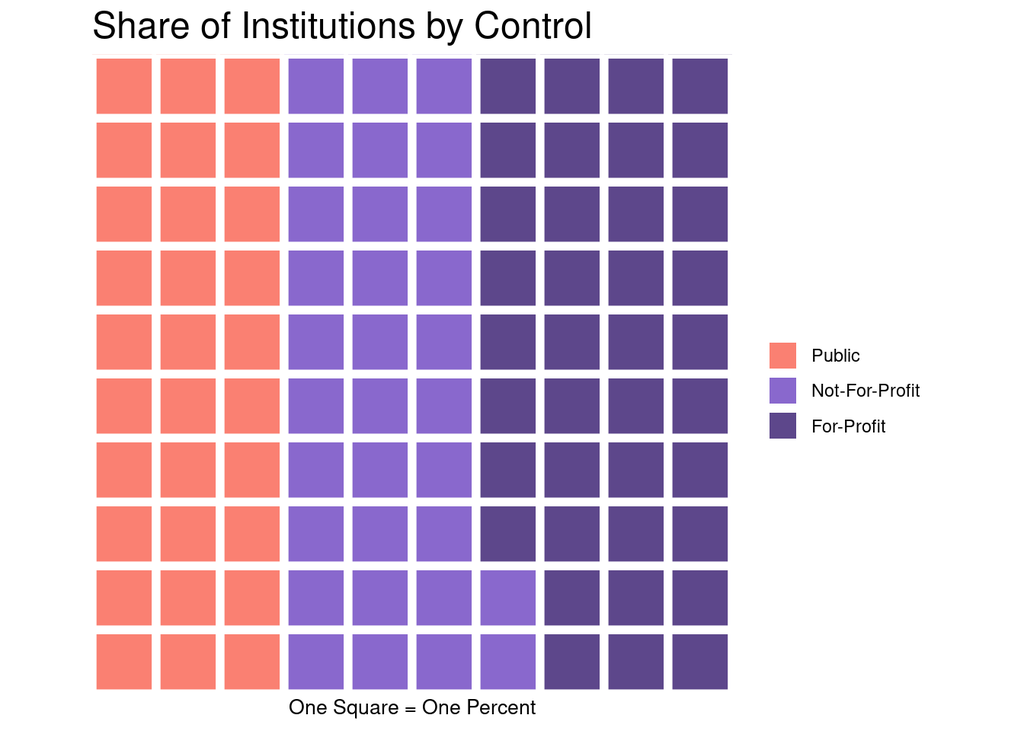

```r
waffle(control, rows = 10, colors = c("salmon", "mediumpurple3", "mediumpurple4"),
       title = "Share of Institutions by Control", xlab = "One Square = One Percent")
```

This plot was created by grouping the data by year and calculating the median revenue and expenses from the main data set. With this representation of the data, we can observe the change of spending and revenue over time, and we are able to compare the rates at which revenue and spending are changing and gather insights by the differences in the curves. What this plot demonstrates is that revenue has experienced substantial growth between 2011 and 2017. It also shows that expenses have also experienced similar rates of growth during this time. There might be some economics at play here in terms of why are they are growing at the rate they are, but there is nothing definitive.

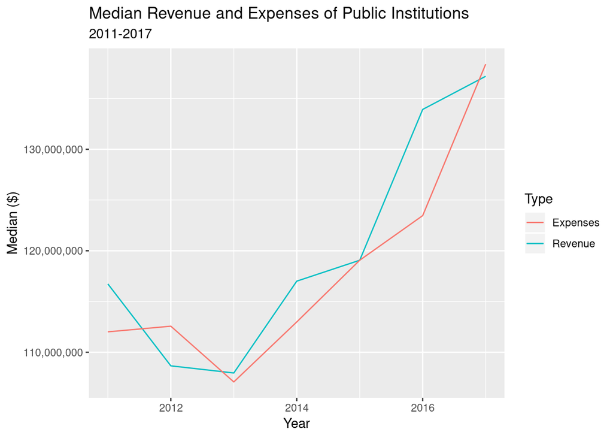

```r
pub_med <- public_joined %>% group_by(YEAR) %>% summarize(MED_REV = median(F1D01, na.rm = T),
                                                          MED_EXP = median(F1D02, na.rm = T),
                                                          MED_COST = median(COSTT4_A, na.rm=T),
                                                          DIFF = MED_REV-MED_EXP)

pub_med %>%
  ggplot(aes(YEAR)) +
  labs(title = "Median Revenue and Expenses of Public Institutions", subtitle = "2011-2017",
       x ="Year", y = "Median ($)", colour = "Type") +
  geom_line(aes(y=MED_REV, col = "Revenue")) +
  geom_line(aes(y=MED_EXP, col = "Expenses")) +
  scale_y_continuous(labels = scales::comma)
```

This is another change over time plot but this time we are comparing the change of debt after graduation and the change of cost of attendance over time. For this plot, the data was grouped by year and the median values for each variable were calculated and plotted as a line chart. The goal of this plot was to see if either variable was growing at a significantly different rate than the other. The differences in the rate of change could suggest the existence of a variable that would diverge these two values from each other that would need to be further researched. This plot in particular shows that the two rates are growing at almost identical rates (around 15 percent). This tells me that the variables are behaving more or less normally and there is no outside variable working as an influence on them.

```r
p1 <- public_joined %>% group_by(YEAR) %>% summarize(MDN_DEBT = median(GRAD_DEBT_MDN, na.rm = T),
                                               MED_COST = median(COSTT4_A, na.rm  = T)) %>%
  ggplot(aes(YEAR, MDN_DEBT)) +
  labs(subtitle = "Public Insituttions 2011 - 2017", x = "Year", y = "Median Value ($)",
       colour = "Type") +
  geom_line(aes(col = "Debt")) +
  geom_line(aes(y = MED_COST, col = "CoA"))
```

```r
p2 <- profit_joined %>% group_by(YEAR) %>% summarize(MDN_DEBT = median(GRAD_DEBT_MDN, na.rm = T),
                                               MED_COST = median(COSTT4_A, na.rm  = T)) %>%
  ggplot(aes(YEAR, MDN_DEBT)) +
  labs(subtitle = "For-Profit Insituttions 2011 - 2017", x = "Year", y = "Median Value ($)",
       colour = "Type") +
  geom_line(aes(col = "Debt")) +
  geom_line(aes(y = MED_COST, col = "CoA"))
```

```r
p3 <- nonprof_joined %>% group_by(YEAR) %>% summarize(MDN_DEBT = median(GRAD_DEBT_MDN, na.rm = T),
                                               MED_COST = median(COSTT4_A, na.rm  = T)) %>%
  ggplot(aes(YEAR, MDN_DEBT)) +
  labs(subtitle = "Not-For-Profit Insituttions 2011 - 2017", x = "Year", y = "Median Value ($)",
       colour = "Type") +
  geom_line(aes(col = "Debt")) +
  geom_line(aes(y = MED_COST, col = "CoA"))
```

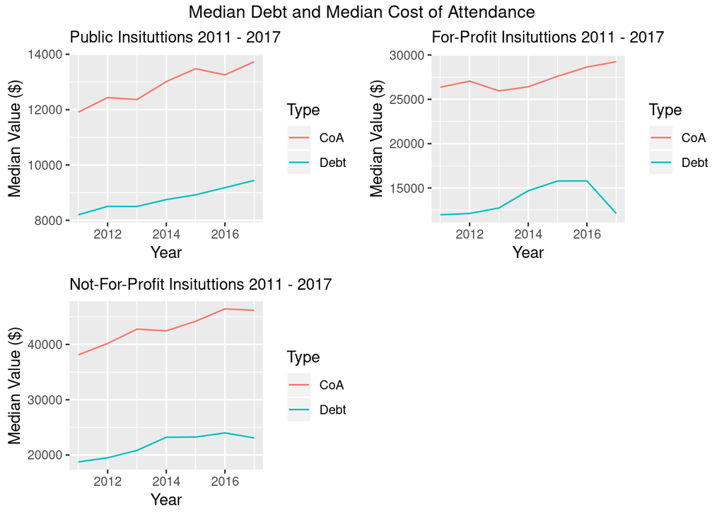

```r
grid.arrange(p1,p2,p3,nrow=2,ncol=2,top = "Median Debt and Median Cost of Attendance",newpage = TRUE)
```

### Additional Data and Insights

The data that I elected to join my primary data set to is the financial data from the Integrated Postsecondary Education Data System (IPEDS) surveys from the same scope as my primary data set. The data is collected and published annually. This data set is relevant to my research because it provides a more comprehensive revenue and expenditure data for the institutions in my primary data set. I have elected to join this data set with my primary data set since the IPEDS provides the data for both data sets so I can know what to expect from the new data set. This new finance data set also provides the additional data I was seeking to make more accurate analyses.

```r
# Selected Columns:
public_2011 <- public_2011 %>% select(UNITID, F1A06, F1C061, F1C191, F1C141, F1C142, F1E11, F1E08, F1E05, F1E06,
                                      F1D01,F1D02, F1C051, YEAR)
```

```r
# Selected columns:
nonprof_2011 <- nonprof_2011 %>% select(UNITID, F2A02, F2C07, F2B01, F2B02, F2D01, YEAR)
```

```r
# Selected columns:
profit_2011 <- profit_2011 %>% select(UNITID, F3A01, F3C05, F3D09, F3D01, F3B02, YEAR)
```

```r
public_joined <- ca_public %>% left_join(public_total, by=c("UNITID", "YEAR"))
nonprof_joined<- ca_private %>% filter(CONTROL==2) %>% left_join(nonprof_total,by=c("UNITID", "YEAR"))
profit_joined <- ca_private %>% filter(CONTROL==3) %>% left_join(profit_total, by=c("UNITID", "YEAR"))

public_joined$X <- NULL
profit_joined$X <- NULL
nonprof_joined$X<- NULL
```

In order to gather the variables relevant to my research question, I transformed the raw form of the finance data set so that it included the various financial information I wanted like the figures for revenue and different expenses. I also mutated a year column to act as way I could match rows from this data set to my primary one. The only columns that matched between the two data sets were the identification number column and the year column. Joining the finance data set to my primary data set allowed me add the additional finance data like revenue and expenses to my first data set. Some compromises had to be made in the process since some institutions in the primary data set did not have a corresponding entry in the finance data set. I chose to keep those entries in the primary data set and have null values in the columns selected from the finance data set because there is still useful data in those entries, and in a data set with an already limited sample size, I wanted as many entries as possible to get a more complete analysis. The number of institutions that didn’t have a corresponding entry was small enough and provided enough of other types of data that I was willing to accept those extra null values in those columns.

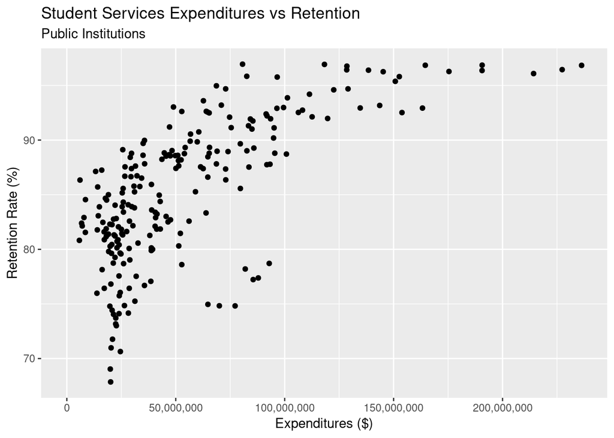

```r
public_joined %>% ggplot(aes(F1C061, RET_FT4*100)) +
  geom_point() +
  labs(title = "Student Services Expenditures vs Retention",
       subtitle = "Public Institutions", x = "Expenditures ($)", y = "Retention Rate (%)") +
  scale_x_continuous(labels=scales::comma)
```

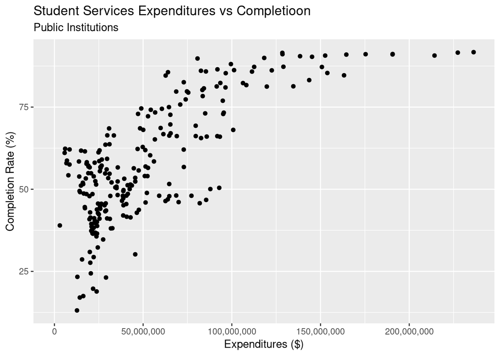

```r
public_joined %>% ggplot(aes(F1C061, C150_4*100)) +
  geom_point() +
  labs(title = "Student Services Expenditures vs Completioon",
       subtitle = "Public Institutions", x = "Expenditures ($)", y = "Completion Rate (%)") +
  scale_x_continuous(labels=scales::comma)
```

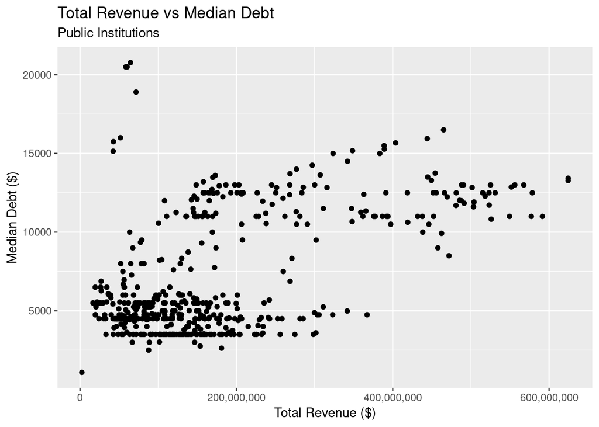

```r
filtered <- public_joined %>% filter(!is.na(DEBT_MDN), !is.na(F1D01), !is.na(GRAD_DEBT_MDN))
filtered %>% ggplot(aes(F1D01, DEBT_MDN)) + geom_point() +
  labs(title = "Total Revenue vs Median Debt", subtitle = "Public Institutions",
       x = "Total Revenue ($)", y = "Median Debt ($)") +
  scale_x_continuous(labels = scales::comma)
```

```r
# Correlation Coefficient of Total revenue and Meditan Debt
cor(filtered$F1D01, filtered$DEBT_MDN)
```

```
## [1] 0.5667359
```

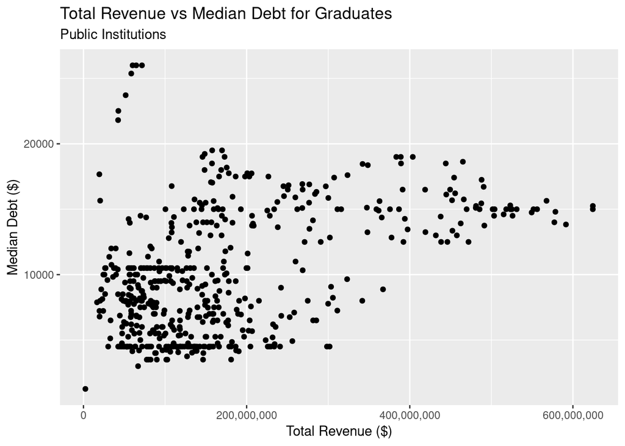

```r
filtered %>% ggplot(aes(F1D01, GRAD_DEBT_MDN)) + geom_point() +
  labs(title = "Total Revenue vs Median Debt for Graduates", subtitle = "Public Institutions",
       x = "Total Revenue ($)", y = "Median Debt ($)") +
  scale_x_continuous(labels = scales::comma)
```

```r
# Correlation Coefficient of Total Revenue and Median Debt of Graduated Students
cor(filtered$F1D01, filtered$GRAD_DEBT_MDN)
```

```
## [1] 0.4521672
```

To achieve this, I plotted a point chart with total revenue and median debt as the axes. From the plot alone, there is no obvious trend. By running the cor() function in R, the correlation coefficient comes out the be around 0.50, a moderate correlation. Without further analysis into the individual data points that make up this plot, there is no way to have conclusive insights. The plot could be misleading.

### Data Issues

One issue that I have found with the accuracy with the data in the data set is that for some variables, the values within them seem so extreme that either they seem like they must be inaccurate or they are flat out, without a doubt, inaccurate. When analyzing all of the California institutions, filtering out rows where the variable representing the number of undergraduate, degree-seeking students is zero; I find that several institutions report this number. Some are just single-year stints, but others like the Southern California University of Health Sciences, report zero undergraduates multiple times. Though there are not many institutions that show this pattern, it shows that erroneous data can exist in the data set and it makes me wary of the accuracy of other variables. Any analysis must be done with some increasing degree of skepticism and many conclusions or interpretations will have inaccuracies. This makes it difficult since not all inaccuracies may be as blatant as zero undergraduate students.

```r
ca_total %>% select(UNITID, INSTNM, ADM_RATE, UGDS, YEAR) %>% filter(UGDS==0) %>% arrange(desc(UNITID))
```

```
##   UNITID                                            INSTNM ADM_RATE UGDS
## 1 459222               Southern California University SOMA       NA    0
## 2 123943                     Marshall B Ketchum University       NA    0
## 3 117672 Southern California University of Health Sciences       NA    0
## 4 117672 Southern California University of Health Sciences       NA    0
## 5 117672 Southern California University of Health Sciences       NA    0
## 6 109086                     American Conservatory Theater       NA    0
## 7 109086                     American Conservatory Theater       NA    0
## 8 109086                     American Conservatory Theater       NA    0
##   YEAR
## 1 2017
## 2 2012
## 3 2011
## 4 2013
## 5 2014
## 6 2013
## 7 2014
## 8 2015
```

My data set is inherently limited because it only represents the students that receive financial aid. Not only is the data set nonrepresentative, it is also incomplete. The incompleteness can be seen in two metrics that are in my data set: admission rate and retention rate. Plotting any graph using any of these two metrics would show that many missing values were removed. In more detail, by filtering out the NAs and calculating the percentage they accounted for, I found that in the collective California data set, almost 70% of all entries had missing retention rate values. A similar statistic is true with completion rates. This significantly decreases the sample size of my analyses and, in turn, the accuracy of the analyses. Insights become skewed when less than one third of the data available can be represented on a plot or can be used in a calculation. These limitations cause the conclusions made to be more reliant on assumptions that a smaller subset can accurately represent the whole. A similar issue is seen in student financial data.

```r
# Percentage of entries with missing Retention rate information
ca_total %>% filter(is.na(RET_FT4)) %>% summarize(Percent_NA = n()/nrow(ca_total) * 100)
```

```
##   Percent_NA
## 1   68.44021
```

```r
# Percentage of entries with missing Completion rate information
ca_total %>% filter(is.na(C150_4)) %>% summarize(Percent_NA = n()/nrow(ca_total) * 100)
```

```
##   Percent_NA
## 1   67.32008
```

You can clearly see the extent of the missing values in my previous retention rate and completion rate plots. In each, there are over 840 values that were removed because of missing values. To put this into perspective: there are only 1078 observations in my `public_joined` data set. This means that only over 77% of my total data available could not be represented in each of those plots. The data available is already limited in its representation of the student body so having the sample size shrunk even further makes me more skeptical of the results of my research. As a result of the sampling limitations and the limitations from missing values within the data set, the sample size available is no where near enough to capture the scope of my research goals and the accuracy in my research, from calculations to representation, are both decreased.

Another issue that I run into is the information gap between the data collectors and aggregators and myself as the data analyst. The creators of the main data set know what values of the other data sets were pulled from to create the aggregated value in the main data set. For example, the cost of attendance value in the main data set gets the values of tuition, fees, and book costs from other data sets to get the average value but I am unable to see the broken down values to see how each category affects the cost. The insights that I can make from data analysis are limited because I am unable to see whether the changes are caused by something institution controlled, like tuition, or something more out of the hands of the institution like the cost of books. Without the ability to see these broken down categories, it becomes more difficult for me to make correlations between costs and institutions’ financial management, the crux of my research.

Through the experience of my research, I will add that insights and analysis of the data set are prone to misinterpretation. Quick, inaccurate conclusions could be made from initial observations, but further insights often tell a different story. Several instances of Simpson’s paradox were found during my research and are highlighted in my Key Findings.

# *Key Findings*

```r
# Median Default rates for 3 year cohort
ca_total %>% group_by(YEAR) %>% summarize(MDN_DEF = median(CDR3, na.rm=T))
```

```
## # A tibble: 7 x 2
##    YEAR MDN_DEF
##   <dbl>   <dbl>
## 1  2011  NA
## 2  2012   0.125
## 3  2013   0.125
## 4  2014   0.117
## 5  2015   0.095
## 6  2016   0.085
## 7  2017   0.085
```

```r
# Median Student Services Expenditures for Public Institutions
public_joined %>% group_by(YEAR) %>% summarize(MDN_SSE = median(F1C061, na.rm=T))
```

```
## # A tibble: 7 x 2
##    YEAR   MDN_SSE
##   <dbl>     <dbl>
## 1  2011 10154312.
## 2  2012 10522790
## 3  2013 10468588
## 4  2014 10954365
## 5  2015 12113030.
## 6  2016 13307163
## 7  2017 14569158
```

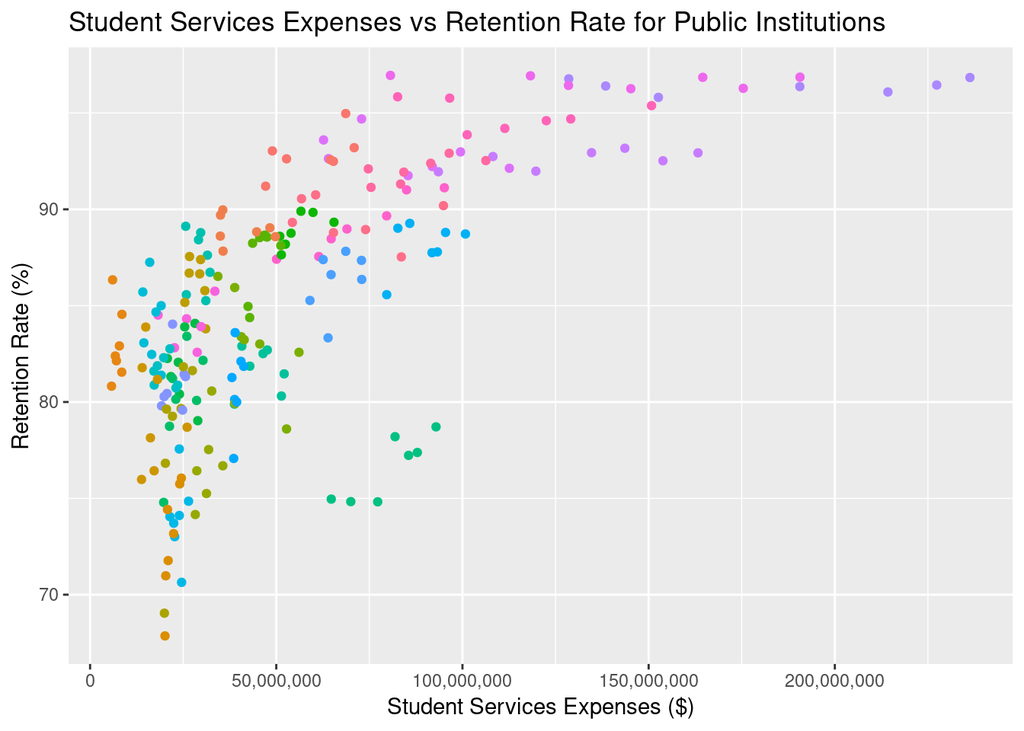

```r
f <- public_joined %>% filter(!is.na(F1C061), !is.na(RET_FT4), !is.na(C150_4))
plot <- f %>% ggplot(aes(F1C061, RET_FT4*100, col = INSTNM)) +
  geom_point(na.rm = T) +
  labs(col = "Institution Name") +
  theme(
    legend.text = element_text(size = 8)
  )

no_leg <- plot +
  theme(legend.position = "none") +
  scale_x_continuous(labels = scales::comma) +
  labs(title = "Student Services Expenses vs Retention Rate for Public Institutions",
       x = "Student Services Expenses ($)",
       y = "Retention Rate (%)")

## https://stackoverflow.com/questions/12041042/how-to-plot-just-the-legends-in-ggplot2
## Function to extract legend
g_legend <- function(a.gplot){
    tmp <- ggplot_gtable(ggplot_build(a.gplot))
    leg <- which(sapply(tmp$grobs, function(x) x$name) == "guide-box")
    legend <- tmp$grobs[[leg]]
    legend
}

no_leg
```